# Chapter 7.rmd

Alex Bayers

11/12/2018

### Problem 3

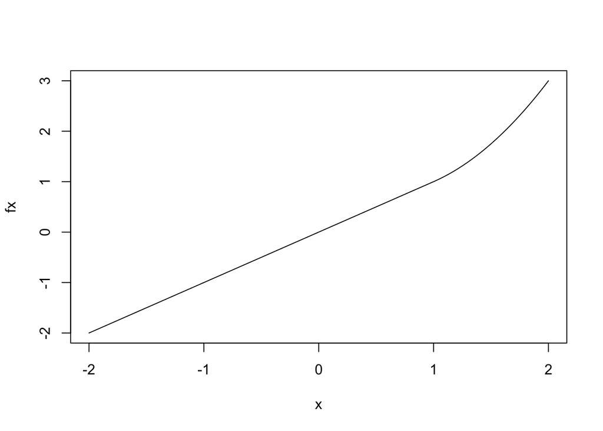

```r
x <- seq(-2, 2, 0.01)
fx <- x + ((x-1)^2)*(x >= 1)
plot(x, fx, type = "l")
```

### Problem 4

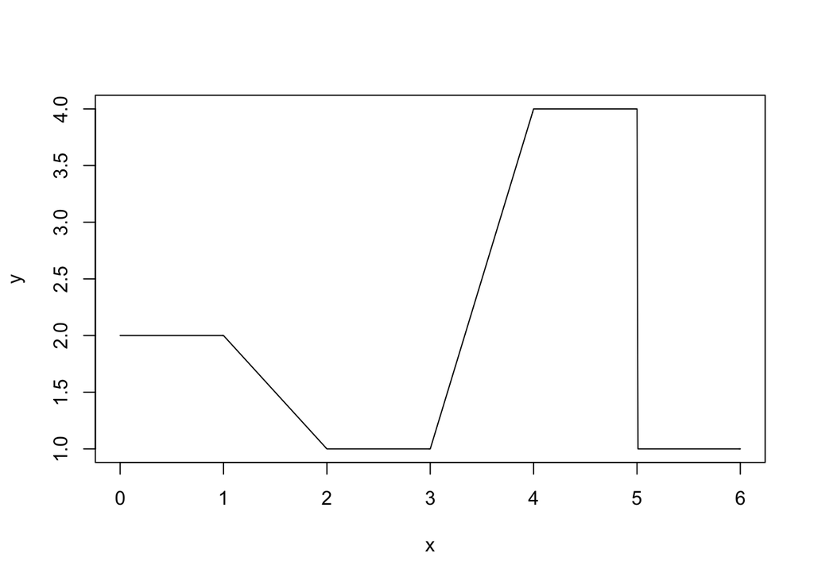

```r
x <- seq(0, 6, 0.01)
b0 <- 1
b1 <- 1
b2 <- 3
f1 <- (0 <= x & x<= 2) - (x-1)*(1 <= x & x <= 2)
f2 <- (x-3)*(3 <= x & x <= 4) + (4 < x & x <= 5)
y <- b0 + b1*f1 + b2*f2
plot(x, y, type = "l")
```

### Problem 6

##### A

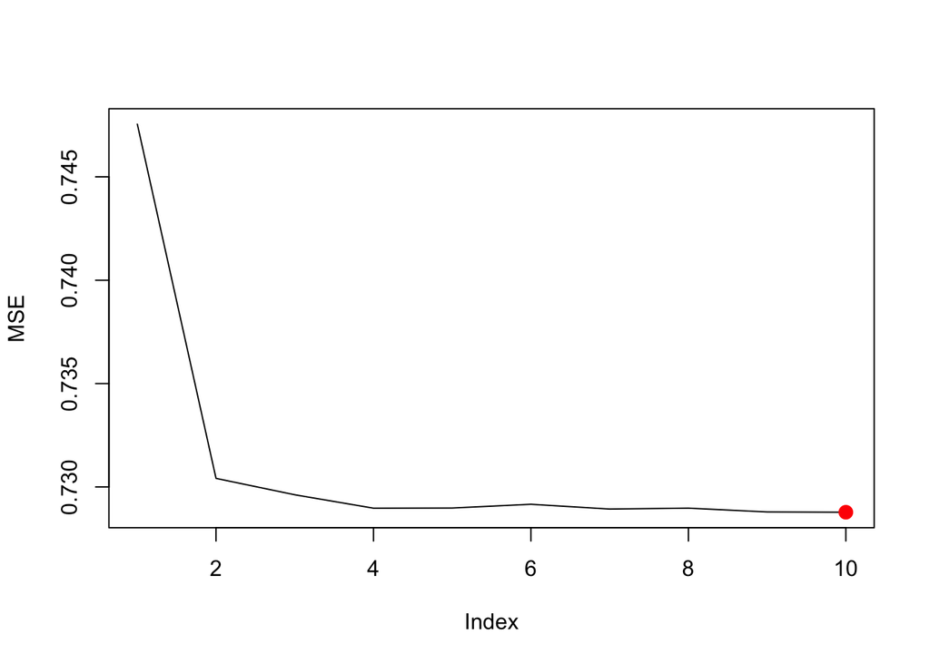

```r
library(ISLR)
library(boot)
set.seed(5)
MSE <- vector(length = 10)
for (k in 1:10){
  wage.lm <- glm(wage ~ poly(age, k, raw = FALSE), data = Wage)
  wage.cv <- cv.glm(Wage, wage.lm, K=30)
  MSE[k] <- sqrt(wage.cv$delta[2]/3000)
}
plot(MSE, type = "l")
points(which.min(MSE),MSE[which.min(MSE)],col="red",cex=2,pch=20)
```

```r
fit.1=lm(wage~age,data=Wage)
fit.2=lm(wage~poly(age, 2),data=Wage)
fit.3=lm(wage~poly(age, 3),data=Wage)
fit.4=lm(wage~poly(age, 4),data=Wage)
fit.5=lm(wage~poly(age, 5),data=Wage)
fit.6=lm(wage~poly(age, 6),data=Wage)
fit.7=lm(wage~poly(age, 7),data=Wage)
fit.8=lm(wage~poly(age, 8),data=Wage)
fit.9=lm(wage~poly(age, 9),data=Wage)
fit.10=lm(wage~poly(age, 10),data=Wage)
anova(fit.1, fit.2, fit.3, fit.4, fit.5, fit.6, fit.7, fit.8, fit.9, fit.10)
```

```
## Analysis of Variance Table
##
## Model  1: wage ~ age
## Model  2: wage ~ poly(age, 2)
## Model  3: wage ~ poly(age, 3)
## Model  4: wage ~ poly(age, 4)
## Model  5: wage ~ poly(age, 5)
## Model  6: wage ~ poly(age, 6)
## Model  7: wage ~ poly(age, 7)
## Model  8: wage ~ poly(age, 8)
## Model  9: wage ~ poly(age, 9)
## Model 10: wage ~ poly(age, 10)
##    Res.Df     RSS Df Sum of Sq        F    Pr(>F)
## 1    2998 5022216
## 2    2997 4793430  1    228786 143.7638 < 2.2e-16 ***
## 3    2996 4777674  1     15756   9.9005  0.001669 **
## 4    2995 4771604  1      6070   3.8143  0.050909 .
## 5    2994 4770322  1      1283   0.8059  0.369398
## 6    2993 4766389  1      3932   2.4709  0.116074
## 7    2992 4763834  1      2555   1.6057  0.205199
## 8    2991 4763707  1       127   0.0796  0.777865
## 9    2990 4756703  1      7004   4.4014  0.035994 *
## 10   2989 4756701  1         3   0.0017  0.967529
## ---
## Signif. codes:  0 '***' 0.001 '**' 0.01 '*' 0.05 '.' 0.1 ' ' 1
```

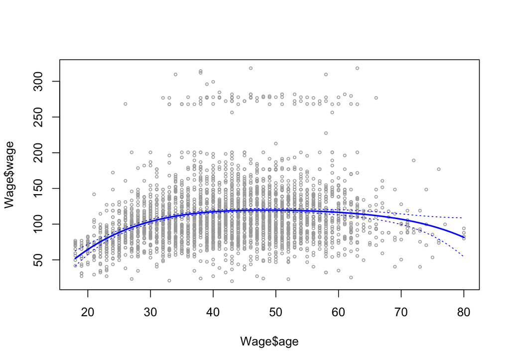

```r
fit.4.predict <- lm(wage ~ age + I(age^2) + I(age^3) + I(age^4), data = Wage)
agelims <- range(Wage$age)
age.range <- seq(from = agelims[1], to = agelims[2])
preds <- predict(fit.4.predict, newdata = list(age = age.range), se = TRUE)
se.bands <- cbind(preds$fit + 2*preds$se.fit, preds$fit - 2*preds$se.fit)
plot(Wage$age, Wage$wage, xlim = agelims, cex = .5, col="darkgrey")
lines(age.range, preds$fit, lwd = 2, col = "blue")
matlines(age.range, se.bands, lwd = 1, col = "blue", lty = 3)
```

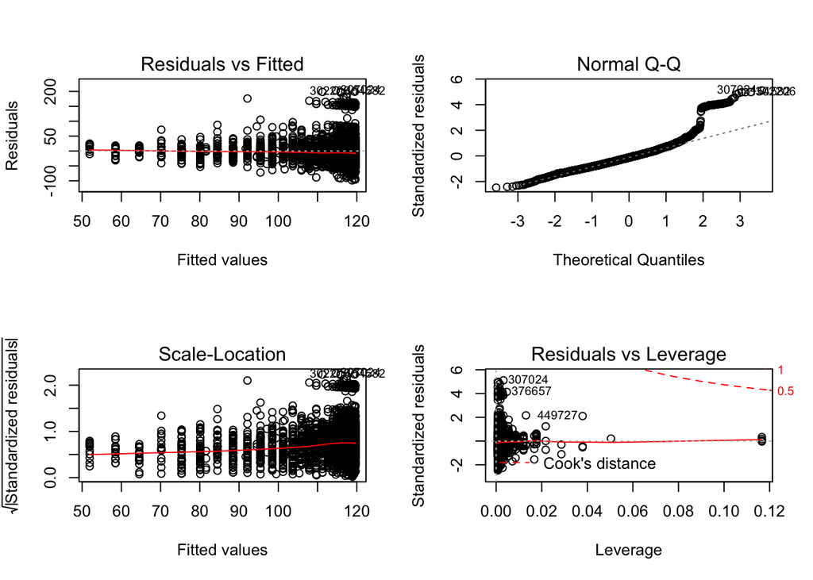

```r
par(mfrow=c(2,2))
plot(fit.4)
```

The MSE is minized at a tenth order polynomial. The anova results indicate minimal gain after the fourth degree polynomial (The statistical significance on the 9th degree term seems like it could be coming entirely from chance). Looking at the diagnostics there are clear issues with the model fit of this plot.

##### B

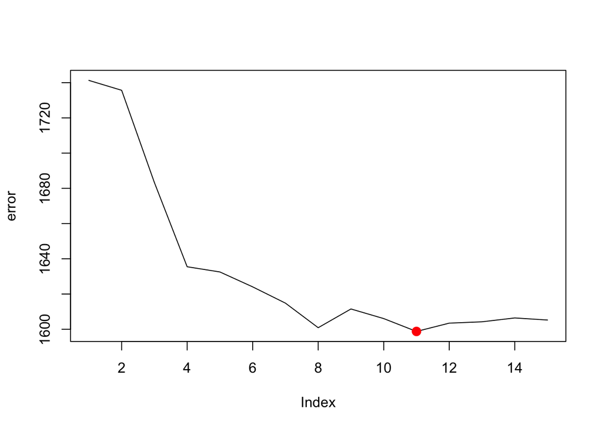

```r
set.seed(5)
error <- vector(length=10)
error[1] <- var(Wage$wage)
for (i in 2:15){
  Wage$cut.table <- cut(Wage$age, breaks = i)
  fit <- glm(wage ~ cut.table, data = Wage)
  fit.cv <- cv.glm(data = Wage, glmfit = fit, K=10)
  error[i] <- fit.cv$delta[1]
}
par(mfrow = c(1,1))
plot(error, type = "l")
points(which.min(error),error[which.min(error)],col="red",cex=2,pch=20)
```

```r
print(error)
```

```
##  [1] 1741.276 1735.667 1683.285 1635.487 1632.526 1624.066 1614.830
##  [8] 1600.881 1611.519 1606.060 1598.761 1603.474 1604.234 1606.425
## [15] 1605.238
```

Either 8 or 11 cuts seem to minimize the CV error. 11 cuts results in a slightly lower varaiance as compared to 8 cuts, but only marginally so.

### 7

```r
maritl.wage <- lm(wage ~ maritl, data = Wage)
summary(maritl.wage)
```

```
##
## Call:
## lm(formula = wage ~ maritl, data = Wage)
##
## Residuals:
##     Min      1Q  Median      3Q     Max
## -98.775 -24.788  -4.754  15.845 221.595
##
## Coefficients:
##                    Estimate Std. Error t value Pr(>|t|)
## (Intercept)          92.735      1.582  58.608  < 2e-16 ***
## maritl2. Married     26.126      1.813  14.413  < 2e-16 ***
## maritl3. Widowed      6.804      9.375   0.726  0.46804
## maritl4. Divorced    10.425      3.234   3.224  0.00128 **
## maritl5. Separated    8.481      5.657   1.499  0.13392
## ---
## Signif. codes:  0 '***' 0.001 '**' 0.01 '*' 0.05 '.' 0.1 ' ' 1
##
## Residual standard error: 40.28 on 2995 degrees of freedom
## Multiple R-squared:  0.06954,    Adjusted R-squared:  0.0683
## F-statistic: 55.96 on 4 and 2995 DF,  p-value: < 2.2e-16
```

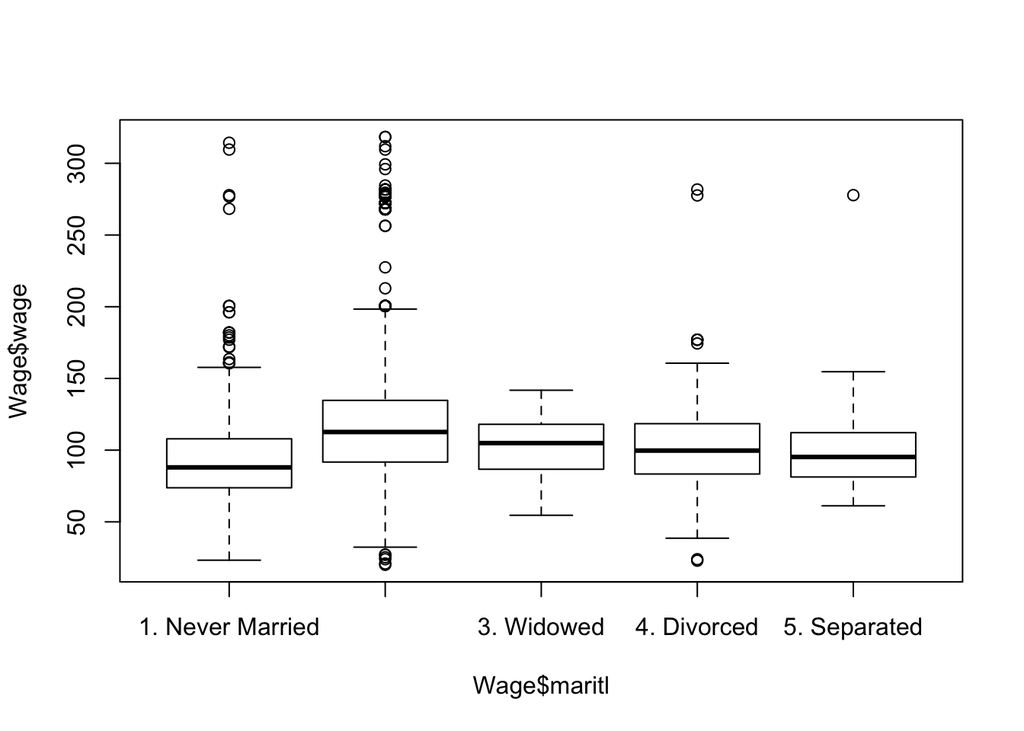

```r
plot(Wage$wage ~ Wage$maritl)
```

```r
race.wage <- lm(wage ~ race, data = Wage)
summary(race.wage)
```

```
##
## Call:
## lm(formula = wage ~ race, data = Wage)
##
## Residuals:
##     Min      1Q  Median      3Q     Max
## -92.478 -24.708  -6.251  17.283 216.741
##
## Coefficients:
##              Estimate Std. Error t value Pr(>|t|)
## (Intercept)  112.5637     0.8333 135.088  < 2e-16 ***
## race2. Black -10.9625     2.5634  -4.276 1.96e-05 ***
## race3. Asian   7.7246     3.1236   2.473  0.01345 *
## race4. Other -22.5903     6.8726  -3.287  0.00102 **
## ---
## Signif. codes:  0 '***' 0.001 '**' 0.01 '*' 0.05 '.' 0.1 ' ' 1
##
## Residual standard error: 41.5 on 2996 degrees of freedom
## Multiple R-squared:  0.0121, Adjusted R-squared:  0.01112
## F-statistic: 12.24 on 3 and 2996 DF,  p-value: 5.89e-08
```

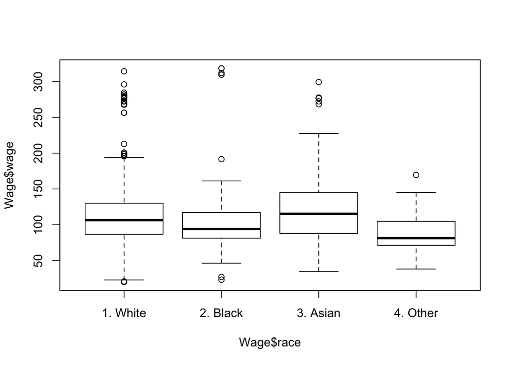

```r
plot(Wage$wage ~ Wage$race)
```

```r
jobclass.wage <- lm(wage ~ jobclass, data = Wage)
summary(jobclass.wage)
```

```
##
## Call:
## lm(formula = wage ~ jobclass, data = Wage)
##
## Residuals:
##      Min       1Q   Median       3Q      Max
## -100.507  -25.362   -6.117   15.697  197.750
##
## Coefficients:
##                        Estimate Std. Error t value Pr(>|t|)
## (Intercept)             103.321      1.039   99.43   <2e-16 ***
## jobclass2. Information   17.272      1.492   11.58   <2e-16 ***
## ---
## Signif. codes:  0 '***' 0.001 '**' 0.01 '*' 0.05 '.' 0.1 ' ' 1
##
## Residual standard error: 40.83 on 2998 degrees of freedom
## Multiple R-squared:  0.04281,    Adjusted R-squared:  0.04249
## F-statistic: 134.1 on 1 and 2998 DF,  p-value: < 2.2e-16
```

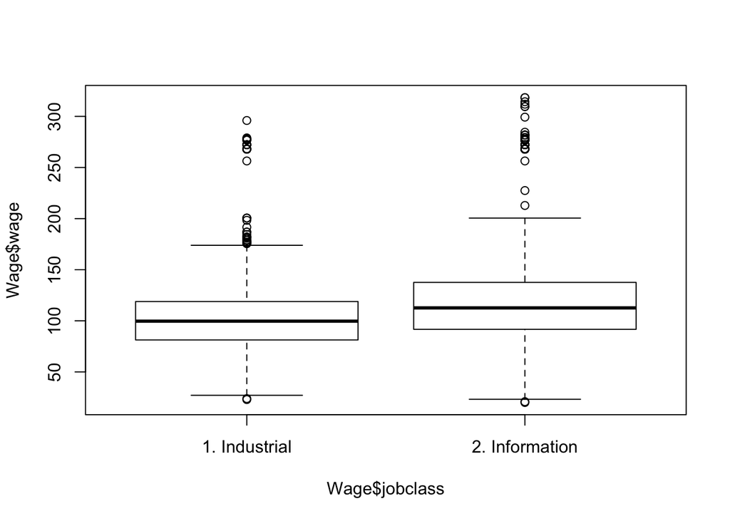

```r
plot(Wage$wage ~ Wage$jobclass)
```

Marital status does seem to have a statistically significant effect, though widowed and separated seem indistinguishable from not married. Race seems to have a statistially significant effect, with Whites and Asians earning more than Black and other. Information workers seem to do better than manual workers.

### 9

##### A

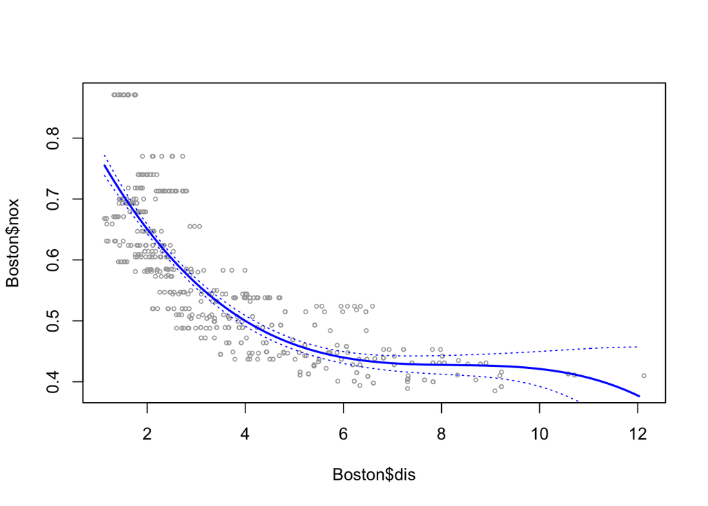

```r
library(MASS)
poly.cubic <- lm(nox ~ dis + I(dis^2) + I(dis^3), data = Boston)
dislims <- range(Boston$dis)
dis.range <- seq(from = dislims[1], to = dislims[2], by = .1)
preds <- predict(poly.cubic, newdata = list(dis = dis.range), se = TRUE)
se.bands <- cbind(preds$fit + 2*preds$se.fit, preds$fit - 2*preds$se.fit)
plot(Boston$dis, Boston$nox, xlim = dislims, cex = .5, col="darkgrey")
lines(dis.range, preds$fit, lwd = 2, col = "blue")
matlines(dis.range, se.bands, lwd = 1, col = "blue", lty = 3)
```

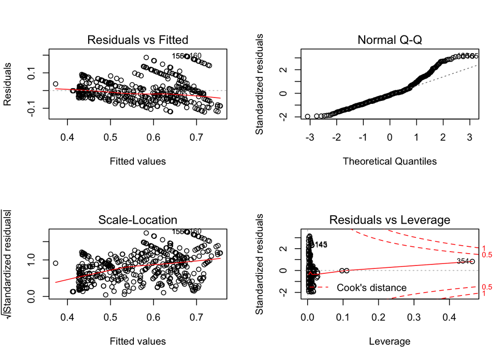

```r
par(mfrow=c(2,2))
plot(poly.cubic)
```

##### B & C

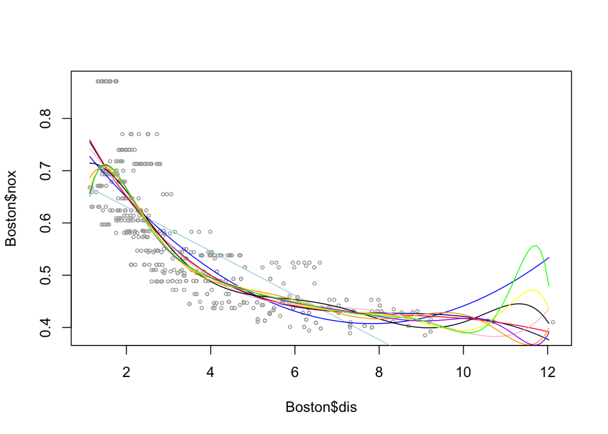

```r
#Fit the models
poly.linear <- glm(nox ~ dis, data = Boston)
poly.quadratic <- glm(nox ~ dis + I(dis^2), data = Boston)
poly.cubic <- glm(nox ~ dis + I(dis^2) + I(dis^3), data = Boston)
poly.quartic <- glm(nox ~ dis + I(dis^2) + I(dis^3) + I(dis^4), data = Boston)
poly.5th <- glm(nox ~ dis + I(dis^2) + I(dis^3) + I(dis^4) + I(dis^5), data = Boston)
poly.6th <- glm(nox ~ dis + I(dis^2) + I(dis^3) + I(dis^4) + I(dis^5) + I(dis^6), data = Boston)
poly.7th <- glm(nox ~ dis + I(dis^2) + I(dis^3) + I(dis^4) + I(dis^5) + I(dis^6) + I(dis^7), data = Boston)
poly.8th <- glm(nox ~ dis + I(dis^2) + I(dis^3) + I(dis^4) + I(dis^5) + I(dis^6) + I(dis^7) + I(dis^8), data = Boston)
poly.9th <- glm(nox ~ dis + I(dis^2) + I(dis^3) + I(dis^4) + I(dis^5) + I(dis^6) + I(dis^7) + I(dis^8) + I(dis^9), data = Boston)
poly.10th <- glm(nox ~ dis + I(dis^2) + I(dis^3) + I(dis^4) + I(dis^5) + I(dis^6) + I(dis^7) + I(dis^8) + I(dis^9) + I(dis^10), data = Boston)

#Fit the cv.glm objects
cv.linear <- cv.glm(Boston, poly.linear)
cv.quadratic <- cv.glm(Boston, poly.quadratic)
cv.cubic <- cv.glm(Boston, poly.cubic)
cv.quartic <- cv.glm(Boston, poly.quartic)
cv.5th <- cv.glm(Boston, poly.5th)
cv.6th <- cv.glm(Boston, poly.6th)
cv.7th <- cv.glm(Boston, poly.7th)
cv.8th <- cv.glm(Boston, poly.8th)
cv.9th <- cv.glm(Boston, poly.9th)
cv.10th <- cv.glm(Boston, poly.10th)

#Build the fits
preds.1st <- predict(poly.linear, newdata = list(dis = dis.range), se = TRUE)
preds.2nd <- predict(poly.quadratic, newdata = list(dis = dis.range), se = TRUE)
preds.3rd <- predict(poly.cubic, newdata = list(dis = dis.range), se = TRUE)
preds.4th <- predict(poly.quartic, newdata = list(dis = dis.range), se = TRUE)
preds.5th <- predict(poly.5th, newdata = list(dis = dis.range), se = TRUE)
preds.6th <- predict(poly.6th, newdata = list(dis = dis.range), se = TRUE)
preds.7th <- predict(poly.7th, newdata = list(dis = dis.range), se = TRUE)
preds.8th <- predict(poly.8th, newdata = list(dis = dis.range), se = TRUE)
preds.9th <- predict(poly.9th, newdata = list(dis = dis.range), se = TRUE)
preds.10th <- predict(poly.10th, newdata = list(dis = dis.range), se = TRUE)

#Graph the fits
par(mfrow=c(1,1))
plot(Boston$dis, Boston$nox, xlim = dislims, cex = .5, col="darkgrey")
lines(dis.range, preds.1st$fit, lwd = 1, col = "lightblue")
lines(dis.range, preds.2nd$fit, lwd = 1, col = "blue")
lines(dis.range, preds.3rd$fit, lwd = 1, col = "darkblue")
lines(dis.range, preds.4th$fit, lwd = 1, col = "red")
lines(dis.range, preds.5th$fit, lwd = 1, col = "pink")
lines(dis.range, preds.6th$fit, lwd = 1, col = "black")
lines(dis.range, preds.7th$fit, lwd = 1, col = "orange")
lines(dis.range, preds.8th$fit, lwd = 1, col = "yellow")
lines(dis.range, preds.9th$fit, lwd = 1, col = "purple")
lines(dis.range, preds.10th$fit, lwd = 1, col = "green")
```

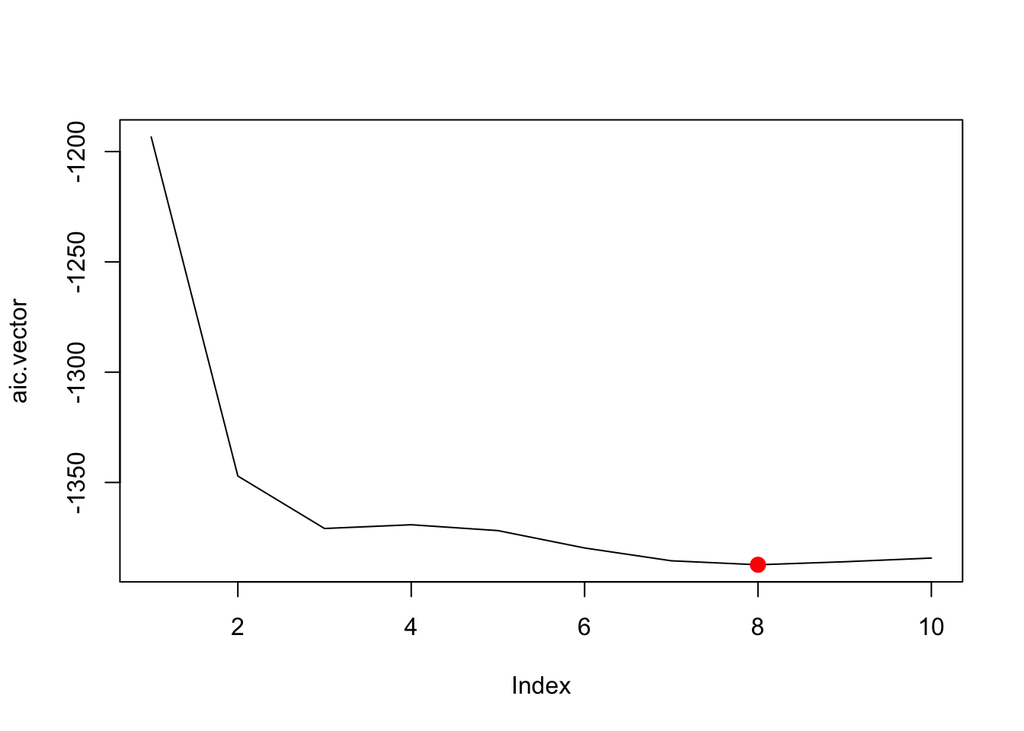

```r
aic.vector <- c(poly.linear$aic, poly.quadratic$aic, poly.cubic$aic, poly.quartic$aic, poly.5th$aic, poly.6th$aic, poly.7th$aic, poly.8th$aic, poly.9th$aic, poly.10th$aic)
plot(aic.vector, type = "l")
points(which.min(aic.vector), min(aic.vector),col="red",cex=2,pch=20)
```

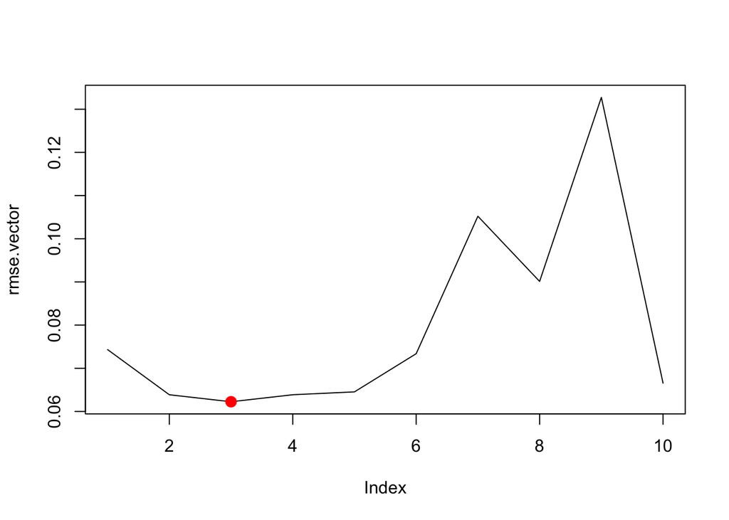

```r
rmse.vector <- c(cv.linear$delta[1]^.5, cv.quadratic$delta[1]^.5, cv.cubic$delta[1]^.5, cv.quadratic$delta[1]^.5, cv.5th$delta[1]^.5, cv.6th$delta[1]^.5, cv.7th$delta[1]^.5, cv.8th$delta[1]^.5, cv.9th$delta[1]^.5, cv.10th$delta[1]^.5)
plot(rmse.vector, type = "l")
points(which.min(rmse.vector), min(rmse.vector),col="red",cex=2,pch=20)
```

AIC suggests an 8th order model, but MSE implies a 3rd degree model.

##### D

```r
library(splines)
splines.fit <- lm(nox ~ bs(dis, df = 4), data = Boston)
summary(splines.fit)
```

```
##
## Call:
## lm(formula = nox ~ bs(dis, df = 4), data = Boston)
##
## Residuals:
##       Min        1Q    Median        3Q       Max
## -0.124622 -0.039259 -0.008514  0.020850  0.193891
##
## Coefficients:
##                  Estimate Std. Error t value Pr(>|t|)
## (Intercept)       0.73447    0.01460  50.306  < 2e-16 ***
## bs(dis, df = 4)1 -0.05810    0.02186  -2.658  0.00812 **
## bs(dis, df = 4)2 -0.46356    0.02366 -19.596  < 2e-16 ***
## bs(dis, df = 4)3 -0.19979    0.04311  -4.634 4.58e-06 ***
## bs(dis, df = 4)4 -0.38881    0.04551  -8.544  < 2e-16 ***
## ---
## Signif. codes:  0 '***' 0.001 '**' 0.01 '*' 0.05 '.' 0.1 ' ' 1
##
## Residual standard error: 0.06195 on 501 degrees of freedom
## Multiple R-squared:  0.7164, Adjusted R-squared:  0.7142
## F-statistic: 316.5 on 4 and 501 DF,  p-value: < 2.2e-16
```

```r
attr(bs(Boston$dis, df=4), "knots")
```

```
##     50%
## 3.20745
```

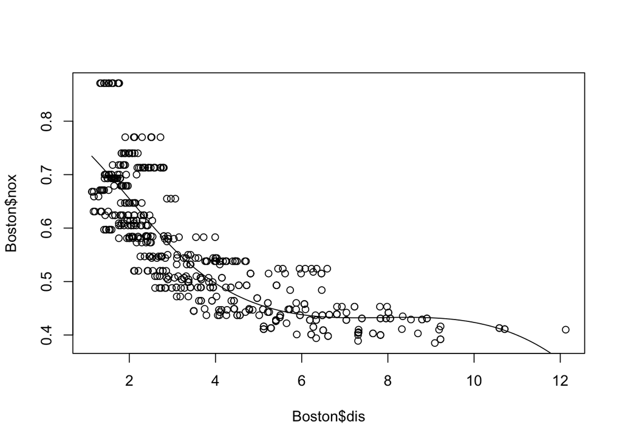

```r
splines.predict <- predict(splines.fit, newdata = list(dis = dis.range))
plot(Boston$dis, Boston$nox)
lines(dis.range, splines.predict,type = "l")
```

##### E

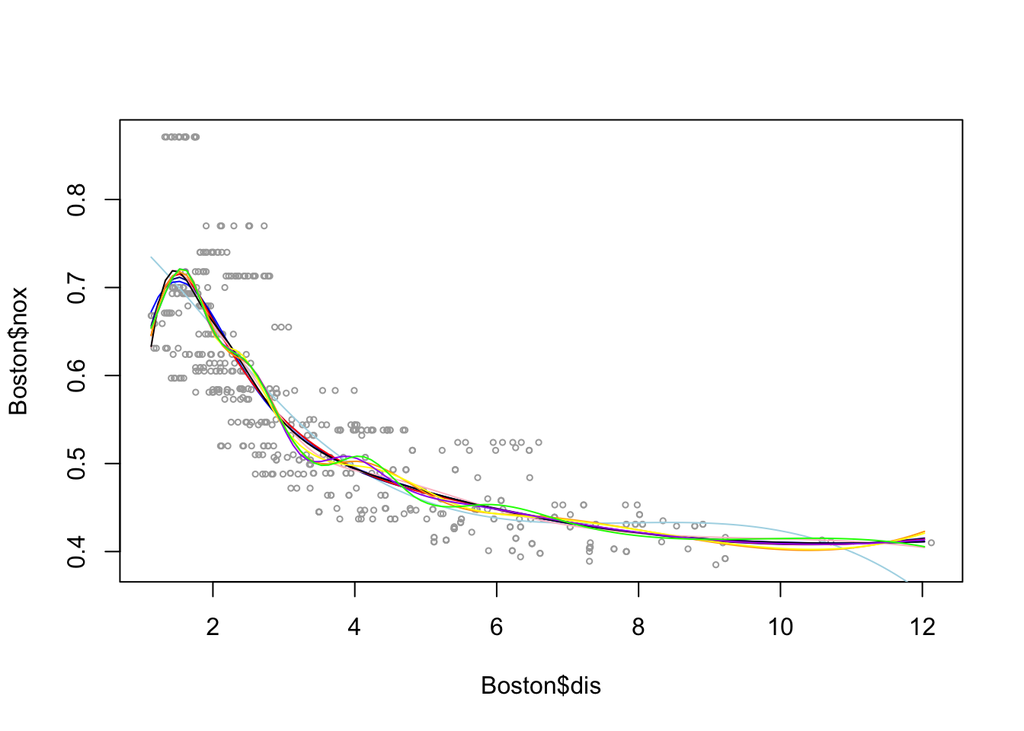

```r
col <- c("lightblue", "blue", "darkblue", "red", "pink", "black", "orange", "yellow", "purple", "green")
rss <- vector(length=10)
plot(Boston$dis, Boston$nox, xlim = dislims, cex = .5, col="darkgrey")
for (i in 1:10){
  model.fit <- lm(nox ~ bs(dis, df = i+3), data = Boston)
  splines.predict <- predict(model.fit, newdata = list(dis = dis.range))
  rss[i] <- sum((predict(model.fit) - Boston$nox)^2)
  lines(dis.range, splines.predict,type = "l", col = col[i])
}
```

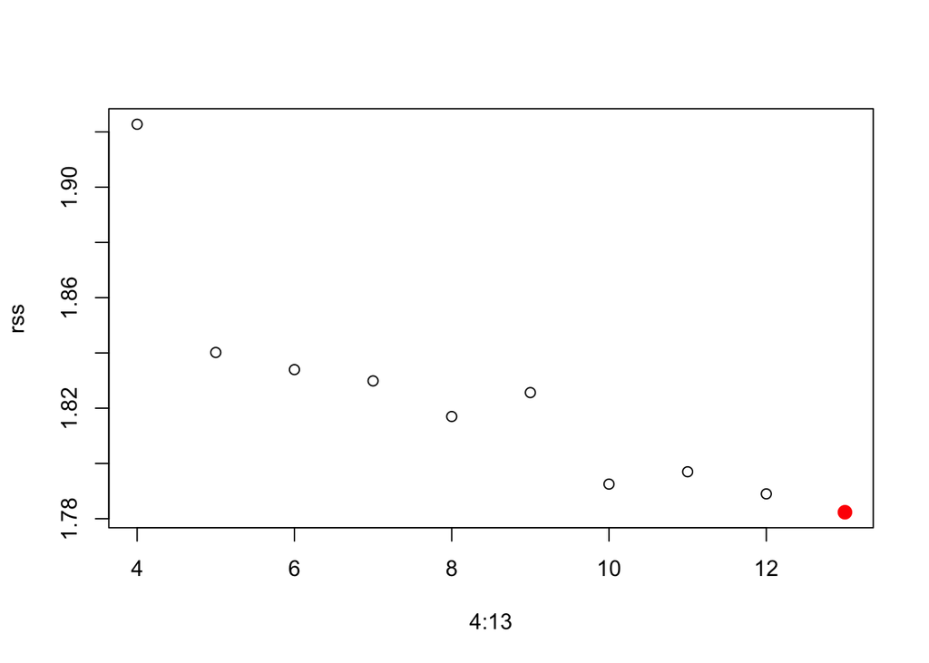

```r
plot(x = 4:13, y = rss)
points(which.min(rss)+3, min(rss), col="red",cex=2,pch=20)
```

Within sample df = 13 fits best, but this is to be expected given that it is within sample.

##### F

```r
set.seed(7)
cv <- vector(length=15)
for (i in 1:15){
  model.fit <- glm(nox ~ bs(dis, df = i+2), data = Boston)
  cv[i] <- cv.glm(Boston, model.fit, K=10)$delta[1]
}
```

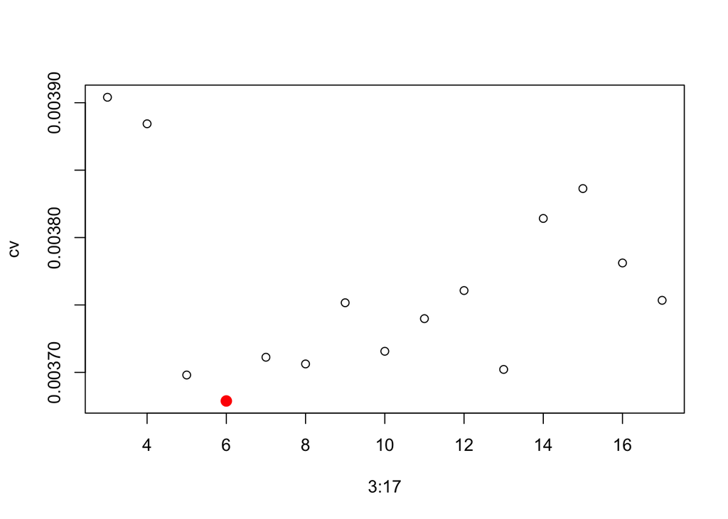

```r
plot(x = 3:17, y = cv)
points(which.min(cv)+2, min(cv), col="red",cex=2,pch=20)
```

We see the test error is minimized for 6 degrees of freedom.

### 10

##### A

```r
library(leaps)
predict.regsubsets <- function(object ,newdata ,id ,...){
  form=as.formula(object$call [[2]])
  mat=model.matrix(form,newdata)
  coefi=coef(object ,id=id)
  xvars=names(coefi)
  mat[,xvars]%*%coefi
}

set.seed(248)
train.length <- floor(nrow(College)*.5)
sample.seq <- c(rep(TRUE, train.length), rep(FALSE, nrow(College)-train.length))
sampled.seq <- sample(sample.seq, nrow(College), replace = FALSE)
train.set <- College[sampled.seq==TRUE,]
test.set <- College[sampled.seq==FALSE,]
regfit.fwd <- regsubsets(Outstate ~. , data = train.set, method = c("forward"), nvm = 17)
summary(regfit.fwd)
```

```
## Subset selection object
## Call: regsubsets.formula(Outstate ~ ., data = train.set, method = c("forward"),
##     nvm = 17)
## 17 Variables  (and intercept)
##             Forced in Forced out
## PrivateYes      FALSE      FALSE
## Apps            FALSE      FALSE
## Accept          FALSE      FALSE
## Enroll          FALSE      FALSE
## Top10perc       FALSE      FALSE
## Top25perc       FALSE      FALSE
## F.Undergrad     FALSE      FALSE
## P.Undergrad     FALSE      FALSE
## Room.Board      FALSE      FALSE
## Books           FALSE      FALSE
## Personal        FALSE      FALSE
## PhD             FALSE      FALSE
## Terminal        FALSE      FALSE
## S.F.Ratio       FALSE      FALSE
## perc.alumni     FALSE      FALSE
## Expend          FALSE      FALSE
## Grad.Rate       FALSE      FALSE
## 1 subsets of each size up to 17
## Selection Algorithm: forward
##           PrivateYes Apps Accept Enroll Top10perc Top25perc F.Undergrad
## 1  ( 1 )  " "        " "  " "    " "    " "       " "       " "
## 2  ( 1 )  "*"        " "  " "    " "    " "       " "       " "
## 3  ( 1 )  "*"        " "  " "    " "    " "       " "       " "
## 4  ( 1 )  "*"        " "  " "    " "    " "       " "       " "
## 5  ( 1 )  "*"        " "  " "    " "    " "       " "       " "
## 6  ( 1 )  "*"        " "  " "    " "    " "       " "       " "
## 7  ( 1 )  "*"        " "  " "    " "    " "       " "       " "
## 8  ( 1 )  "*"        " "  " "    " "    " "       " "       "*"
## 9  ( 1 )  "*"        " "  "*"    " "    " "       " "       "*"
## 10  ( 1 ) "*"        "*"  "*"    " "    " "       " "       "*"
## 11  ( 1 ) "*"        "*"  "*"    " "    "*"       " "       "*"
## 12  ( 1 ) "*"        "*"  "*"    " "    "*"       " "       "*"
## 13  ( 1 ) "*"        "*"  "*"    "*"    "*"       " "       "*"
## 14  ( 1 ) "*"        "*"  "*"    "*"    "*"       "*"       "*"
## 15  ( 1 ) "*"        "*"  "*"    "*"    "*"       "*"       "*"
```

[output cut: 23 more lines]

```
## 3  ( 1 )  " "         "*"    " "
## 4  ( 1 )  " "         "*"    " "
## 5  ( 1 )  " "         "*"    "*"
## 6  ( 1 )  " "         "*"    "*"
## 7  ( 1 )  "*"         "*"    "*"
## 8  ( 1 )  "*"         "*"    "*"
## 9  ( 1 )  "*"         "*"    "*"
## 10  ( 1 ) "*"         "*"    "*"
## 11  ( 1 ) "*"         "*"    "*"
## 12  ( 1 ) "*"         "*"    "*"
## 13  ( 1 ) "*"         "*"    "*"
## 14  ( 1 ) "*"         "*"    "*"
## 15  ( 1 ) "*"         "*"    "*"
## 16  ( 1 ) "*"         "*"    "*"
## 17  ( 1 ) "*"         "*"    "*"
```

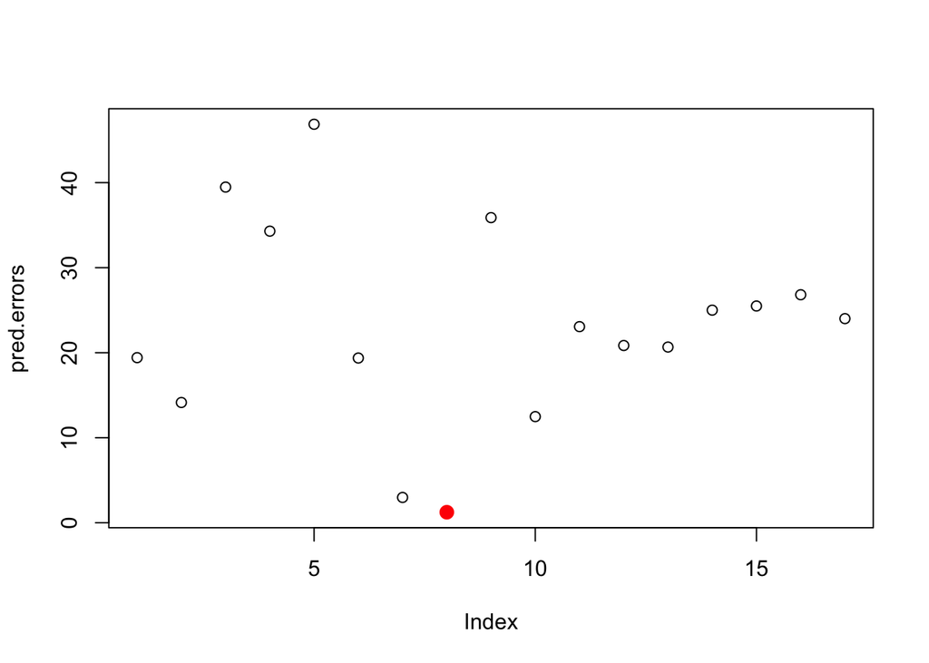

```r
pred.errors <- vector(length=17)
for (i in 1:17){
  pred.matrix <- predict(regfit.fwd, newdata = test.set, id = i)
  pred.errors[i] <- (mean(test.set$Outstate - pred.matrix)^2)^.5
}
plot(pred.errors)
points(which.min(pred.errors), min(pred.errors), col="red",cex=2,pch=20)
```

We try using 8 variables for our model, in line with the min MSE. We include PrivateYes, F.Undergrad, Room.Board, Personal, Terminal, perc.Alumni, Expend, Grad.Rate.

##### B

```r
library(gam)
gam.m1 <- gam(Outstate ~ Private + s(F.Undergrad, 3) + s(Room.Board, 20) + s(Personal, 3) + s(Terminal, 3) + s(perc.alumni, 3) + s(Expend, 20) + s(Grad.Rate, 3), data = train.set)
summary(gam.m1)
```

```
##
## Call: gam(formula = Outstate ~ Private + s(F.Undergrad, 3) + s(Room.Board,
##     20) + s(Personal, 3) + s(Terminal, 3) + s(perc.alumni, 3) +
##     s(Expend, 20) + s(Grad.Rate, 3), data = train.set)
## Deviance Residuals:
##      Min       1Q   Median       3Q      Max
## -7900.95 -1092.44   -17.65  1162.00  6055.98
##
## (Dispersion Parameter for gaussian family taken to be 3418413)
##
##     Null Deviance: 6150845993 on 387 degrees of freedom
## Residual Deviance: 1131493062 on 330.9995 degrees of freedom
## AIC: 6992.787
##
## Number of Local Scoring Iterations: 2
##
## Anova for Parametric Effects
##                    Df     Sum Sq    Mean Sq  F value    Pr(>F)
## Private             1 1643665306 1643665306 480.8269 < 2.2e-16 ***
## s(F.Undergrad, 3)   1   23531039   23531039   6.8836  0.009102 **
## s(Room.Board, 20)   1 1123301923 1123301923 328.6033 < 2.2e-16 ***
## s(Personal, 3)      1   78557622   78557622  22.9807 2.476e-06 ***
## s(Terminal, 3)      1  331447482  331447482  96.9594 < 2.2e-16 ***
## s(perc.alumni, 3)   1  132211439  132211439  38.6763 1.508e-09 ***
## s(Expend, 20)       1  669444473  669444473 195.8348 < 2.2e-16 ***
## s(Grad.Rate, 3)     1   54815017   54815017  16.0352 7.680e-05 ***
## Residuals         331 1131493062    3418413
## ---
## Signif. codes:  0 '***' 0.001 '**' 0.01 '*' 0.05 '.' 0.1 ' ' 1
##
## Anova for Nonparametric Effects
##                   Npar Df Npar F     Pr(F)
## (Intercept)
## Private
## s(F.Undergrad, 3)       2 1.0240   0.36031
## s(Room.Board, 20)      19 1.7913   0.02269 *
## s(Personal, 3)          2 1.6571   0.19227
## s(Terminal, 3)          2 1.3446   0.26207
## s(perc.alumni, 3)       2 1.5072   0.22305
## s(Expend, 20)          19 4.7370 9.813e-10 ***
## s(Grad.Rate, 3)         2 2.1386   0.11944
## ---
## Signif. codes:  0 '***' 0.001 '**' 0.01 '*' 0.05 '.' 0.1 ' ' 1
```

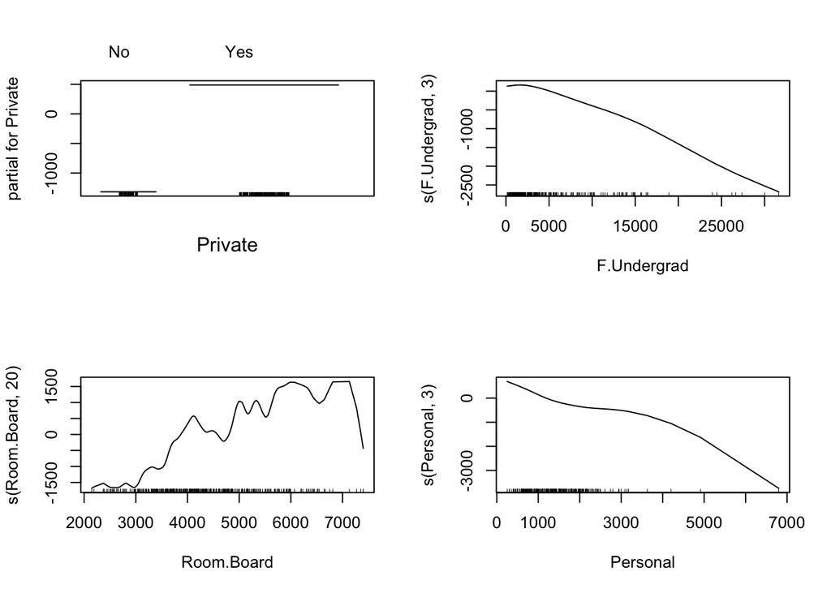

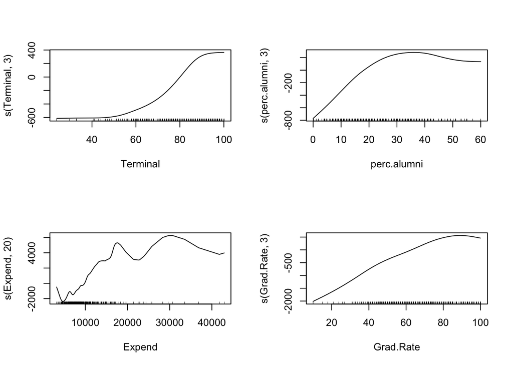

```r
par(mfrow=c(2,2))
plot(gam.m1)
```

### 12

##### A,B,C,D

```r
set.seed(12)
b1 <- .7
b2 <- .9
x1 <- rnorm(100)
x2 <- rnorm(100)
e <- rnorm(100)
y <- b1*x1 + b2*x2 + e
b1.est <- rnorm(1)
a <- y - b1.est*x1
b2.est <- lm(a ~ x2)$coef[2]
a <- y - b2.est*x2
b1.est <- lm(a ~ x1)$coef[2]
```

##### E

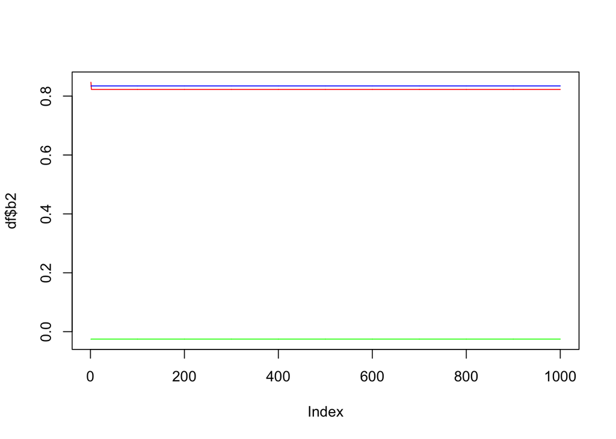

```r
my.matrix <- matrix(NA, nrow = 1000, ncol = 3)
b1.est <- rnorm(1)
b0.est <- 0
for (i in 1:1000){
  a <- y - b1.est*x1
  b2.est <- lm(a ~ x2)$coef[2]
  a <- y - b2.est*x2
  lm.est <- lm(a ~ x1)
  b1.est <- lm.est$coef[2]
  b0.est <- lm.est$coef[1]
  my.matrix[i,] <- c(b0.est, b1.est, b2.est)
}
colnames(my.matrix) <- c('b0', 'b1', 'b2')
df <- data.frame(my.matrix)
par(mfrow = c(1,1))
plot(df$b2, type = 'l', col = 'red', ylim = c(min(df), max(df)))
lines(df$b1, type = 'l', col = 'blue')
lines(df$b0, type = 'l', col = 'green')
```

The fit converges after two iterations, which seems quite good.

##### F

```r
lm.fit <- lm(y ~ x1 + x2)
summary(lm.fit)
```

```
##
## Call:
## lm(formula = y ~ x1 + x2)
##
## Residuals:
##     Min      1Q  Median      3Q     Max
## -2.8022 -0.6244 -0.0259  0.7150  1.8090
##
## Coefficients:
##             Estimate Std. Error t value Pr(>|t|)
## (Intercept) -0.02515    0.10093  -0.249    0.804
## x1           0.83461    0.11718   7.122 1.87e-10 ***
## x2           0.82264    0.10147   8.107 1.59e-12 ***
## ---
## Signif. codes:  0 '***' 0.001 '**' 0.01 '*' 0.05 '.' 0.1 ' ' 1
##
## Residual standard error: 1.009 on 97 degrees of freedom
## Multiple R-squared:  0.5495, Adjusted R-squared:  0.5402
## F-statistic: 59.16 on 2 and 97 DF,  p-value: < 2.2e-16
```

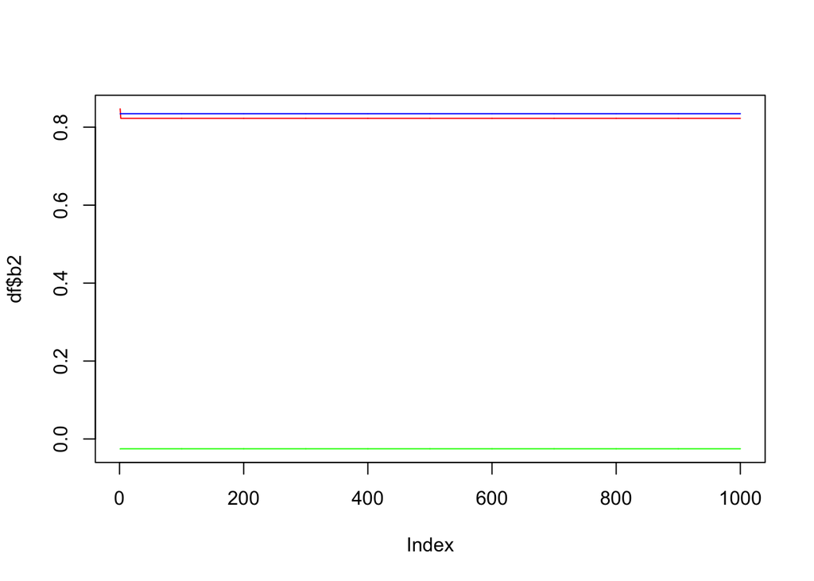

```r
plot(df$b2, type = 'l', col = 'red', ylim = c(min(df), max(df)))
lines(df$b1, type = 'l', col = 'blue')
lines(df$b0, type = 'l', col = 'green')
abline(a = lm.fit$coefs[0], b = 0, col = 'black')
abline(a = lm.fit$coefs[1], b = 0, col = 'purple')
abline(a = lm.fit$coefs[2], b = 0, col = 'orange')
```

So our model converges after two passes.